# depth_native functions

## Select sub, Zthr and Zcontrast

```r
# All of the following will become selector widgets

# SUBID = "sub_02"     # df %>% distinct(sub) to see all available sub
# Zcontrast <- "thresh_zstat1"
# Zthr <- 2.3
# clusterSizeThr <- 50  # to build a meaningful histogram
# h_breaks <- seq(0, 1, 0.05) # set hist breaks to a fixed range

# -----------------------------------------------------------------------------

# Immutable parameters
gitdir <- "/data00/layerfMRI/Github_repo/"
bd <- paste0(gitdir,"layerfMRI/analyses/depth_native/")

library(stringr)
library(tidyr)
library(dplyr)
library(purrr)
select <- dplyr::select
library(ggplot2)
library(tictoc)


julabels <- read.csv("labels_juelich.csv") %>%
  mutate(name = str_replace(name,"['-/]","")) %>%    # get rid of special chars
  mutate(numba = index + 1) %>%
  select(-index)
```

## Create dictionary of data from `list.files`

The magic is provided by `tidyr::separate`

```r
create_dizio_files <- function(data_native_dir = "data_native") {

  df <- list.files("data_native", recursive = T) %>% as.data.frame()
  names(df) <- "fname"


  df <- df %>%
    rowwise() %>%
    tidyr::separate(
      fname, c("sub","contrast","taskrun","zstat"),
      sep = "/", fill = "right", remove = FALSE
    ) %>%
    mutate(taskrun = str_extract(taskrun,"task_[1-4]\\_run_[1-2]")) %>%
    mutate(zstat = str_extract(zstat,"thresh_zstat[1-4]")) %>%
    mutate(pathname = paste0(bd,"/data_native/",fname)) %>%
    dplyr::select(-fname)

  return(df)
}



# ------------------------------  Code for Main -------------------------------
# df <- create_dizio_files()



df <- create_dizio_files()
# show df tree
library(collapsibleTree)
dataset <- df %>% dplyr::select(sub,contrast,taskrun,zstat)
collapsibleTree(dataset, c("sub","contrast","taskrun","zstat"), collapsed = T, zoomable = F)
```

[interactive chart not shown]

## Load Z, D, JU and extract values for sig voxels

Load the nii for Zmaps (thresh_Zstat[1..4]), Depth and JUelich atlases, all in native space:

- Z_nii : 8 for each contrast (Motion, Scrambled, M>S, S>M)
- D_nii : 8, one for each taskrun
- JU_nii : 8, one for each taskrun

Then for each run/contrast 1. threshold the Z_nii to Z_thr and create a Zthr_idx of suprathreshold voxels 2. extract Z_vals, D_vals and JU_vals at the locations of Zthr_idx

```r
library(RNifti)

load_niis <- function(SUBID, Zcontrast) {

  # Load the Z_nii for a given contrast (8, one for each taskrun)
  Z_nii <- df %>%
    filter(sub == SUBID, contrast == "Zstat", zstat == Zcontrast) %>%
    select(pathname) %>% sapply(readNifti)

  # Load the D_nii (8 taskrun)
  D_nii <- df %>%
    filter(sub == SUBID, contrast == "depth") %>%
    select(pathname) %>% sapply(readNifti)

  # Load the JU_nii (8 taskrun)
  JU_nii <- df %>%
    filter(sub == SUBID, contrast == "atlas") %>%
    select(pathname) %>% sapply(readNifti)

  niis <- list(
    Z = Z_nii,
    D = D_nii,
    JU = JU_nii
  )

  return(niis)
}


get_idx_and_vals <- function(Z_thr, Z_nii, D_nii, JU_nii) {

  # Create an index of sig voxels according to Zthr
  Zthr_idx <- sapply(Z_nii, function(x) {which(x > Zthr)})

  # Extract Z, D, JU values at the location of Zthr_idx
  Z_vals <- mapply( function(vols,idx) vols[idx], Z_nii, Zthr_idx )
  D_vals <- mapply( function(depth,idx) depth[idx], D_nii, Zthr_idx )
  JU_vals <- mapply( function(atlas,idx) atlas[idx], JU_nii, Zthr_idx )

  idx_and_vals <- list(
    idx = Zthr_idx,
    zvals = Z_vals,
    depthvals = D_vals,
    juelichvals = JU_vals
  )

  return(idx_and_vals)
}


# ------------------------------  Code for Main -------------------------------

# niis <- load_niis(SUBID, Zcontrast)
#
# Z_nii  <- niis$Z
# D_nii  <- niis$D
# JU_nii <- niis$JU
#
# idx_and_vals <- get_idx_and_vals(Z_thr, Z_nii, D_nii, JU_nii)
#
# Zthr_idx <- idx_and_vals$idx
# Z_vals   <- idx_and_vals$zvals
# D_vals   <- idx_and_vals$depthvals
# JU_vals  <- idx_and_vals$juelichvals
```

## Hist for each Juelich region

- The (outer) Mapply loops on pairs of `[jv = JU_vals[i], dv = D_vals[i]]` for each i-th taskrun
- The (inner) Sapply loops on juelich regions if the numba sig voxels is > clusterSizeThr
- A final Sapply removes the juelich regions where the counts are NULL

```r
get_hist_stats_juelich_ROIs <- function(julabels, JU_vals, D_vals,
                                        clusterSizeThr, h_breaks, thr_Nrun_sig) {

  # Transform julabels to a list to use sapply
  julabels_list <- spread(julabels, key = name, value = numba) %>% as.list()

  # Create a list of length == numba taskruns (8), each one containing
  # a list of counts for each region where the numba of sig voxels is > clusterSizeThr
  tot <- mapply(function(jv, dv) {

    taskrun_count <- sapply(julabels_list, function(ROInumba) {

      idxROI <- which(jv == ROInumba)

      if (length(idxROI) > clusterSizeThr) {
        hcounts <- hist(dv[idxROI], breaks = h_breaks, plot = F)$counts
      }
    })

    taskrun_count <- taskrun_count[!sapply(taskrun_count,is.null)]

  }, JU_vals, D_vals) %>% purrr::flatten()  # remove the outer list layer (i.e. taskrun)



  # determine unique sig ROI names
  activeROIs <- tot %>% names() %>% unique()

  # group by ROI
  grouped <- map(activeROIs, ~ reduce(tot[names(tot) == .x], rbind) ) %>% setNames(activeROIs)

  # (1) remove ROIs where a sig result occurs only in one run
  grouped <- grouped[!sapply(grouped,function(x) is.null(dim(x)) ) ]

  # (2) remove ROIs where a sig result occurs in less than 6/8 runs
  grouped <- grouped[!sapply(grouped,function(x) dim(x)[1] < thr_Nrun_sig)]


  # transform to probabilities, i.e. divide the counts in each row by the sum across columns
  grouped <- lapply(grouped, function(x) x/apply(x, MARGIN = 1, sum))

  # # just checking that the sum of probabilities gives 1
  # # (i.e. to check that I summed across the right margin)
  # lapply(grouped, function(x) apply(x, MARGIN = 1, sum)) %>% print()


  # calculate mean p for each depth across taskrun, i.e. across rows
  MUs  <- lapply(grouped, function(x) apply(x, MARGIN = 2, mean)) %>% as.data.frame()

  # calculate standard error of p across depth
  sterr <- function(x) {sd(x)/sqrt(length(x))}
  ERRs <- lapply(grouped, function(x) apply(x, MARGIN = 2, sterr)) %>% as.data.frame()

  hist_stats = list(
    means = MUs,
    error = ERRs
  )

  return(hist_stats)
}


# ------------------------------  Code for Main -------------------------------

# thr_Nrun_sig=6,
# clusterSizeThr = 50,
# h_breaks = seq(0, 1, 0.05)

# hist_stats <- get_hist_stats_juelich_ROIs(julabels, JU_vals, D_vals, clusterSizeThr, h_breaks, thr_Nrun_sig)
```

## Main function to get contrast-specific results

This uses all the functions created above, and returns the mean and sterr of counts across taskrun for a specific contrast.  
I **need** to make this function since I need to get the histograms for *two* contrasts at a time. Rewriting everything would be prone to mistakes and not elegant (i.e. easy to read/edit).

```
get_contrast_specific_results(Zcontrast)
├── load_niis(SUBID, Zcontrast)
├── get_idx_and_vals(Z_thr, Z_nii, D_nii, JU_nii)
└── get_hist_stats_juelich_ROIs(julabels, JU_vals, D_vals,
                                clusterSizeThr, h_breaks, thr_Nrun_sig)
```

```r
# Main function, to be run for each contrast
get_contrast_specific_results <- function(Zcontrast) {

  # Load Z, D, JU niftis (24)
  niis <- load_niis(SUBID, Zcontrast)

  Z_nii  <- niis$Z
  D_nii  <- niis$D
  JU_nii <- niis$JU


  # Extract values for sig voxels in Zstat, Depth and JUelich native maps
  idx_and_vals <- get_idx_and_vals(Z_thr, Z_nii, D_nii, JU_nii)

  Zthr_idx <- idx_and_vals$idx
  Z_vals   <- idx_and_vals$zvals
  D_vals   <- idx_and_vals$depthvals
  JU_vals  <- idx_and_vals$juelichvals


  # (1) Estimate the distribution of sig voxels at different depths for each ROI in the juelich atlas.
  # (2) Exclude ROIs where the numba of sig voxels is < clusterSizeThr in less than 6/8 runs
  # (3) Retain mean and standard error across runs
  hist_stats <- get_hist_stats_juelich_ROIs(julabels, JU_vals, D_vals,
                                            clusterSizeThr, h_breaks, thr_Nrun_sig)

  return(hist_stats)

}
```

## Main process

```r
# df %>% dplyr::select(sub) %>% unique()

# Create dictionary of data from list.files()
df <- create_dizio_files()


SUBID = "sub_11"     # df %>% distinct(sub) to see all available sub
Zthr <- 2.3
clusterSizeThr <- 50        # to build a meaningful histogram
h_breaks <- seq(0, 1, 0.05) # set hist breaks to a fixed range
thr_Nrun_sig <- 4           # min numba of runs in which there are N sig voxels above clusterSizeThr



Motion_res <- get_contrast_specific_results(Zcontrast = "thresh_zstat1")

Scrambled_res <- get_contrast_specific_results(Zcontrast = "thresh_zstat2")



# Prepare the results for plotting using the magic tidyverse:
# (1) put the resulting df for all contrasts in one list
# (2) add depth and contrast factor
# (3) tidy (i.e. WIDE -> LONG)
# (4) bind_rows all the df into one
res_means <- list(Motion_res$means, Scrambled_res$means) %>%
  map(~ .x %>% mutate(depth = 1:nrow(.x)/nrow(.x)) ) %>%
  map2(. , c("Motion","Scrambled"),  ~ .x %>% mutate(contrast = .y)) %>%
  map(~ .x %>% gather(contains("GM"), key = "ROI", value = "proportion") ) %>%
  reduce(bind_rows)

res_error <- list(Motion_res$error, Scrambled_res$error) %>%
  map(~ .x %>% mutate(depth = 1:nrow(.x)/nrow(.x)) ) %>%
  map2(. , c("Motion","Scrambled"),  ~ .x %>% mutate(contrast = .y)) %>%
  map(~ .x %>% gather(contains("GM"), key = "ROI", value = "error") ) %>%
  reduce(bind_rows)

res <- inner_join(res_means, res_error, c("contrast","ROI","depth"))
```

## sub_11

## Barplot with two contrasts and errorbars

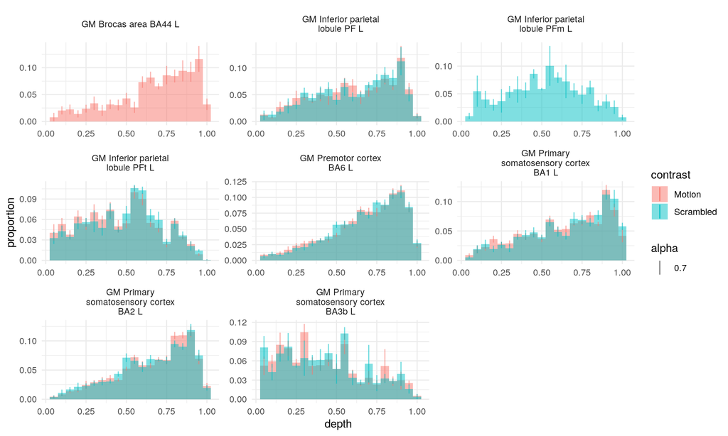

```r
library(ggthemes)

res %>%
  mutate(ROI = str_replace_all(ROI, "_", " ")) %>%
  ggplot( aes(x = depth, y = proportion, fill = contrast) ) +
  geom_bar(stat = "identity", width = 0.05, position = position_identity(), alpha = 0.5) +
  geom_linerange(aes(ymin = proportion - error, ymax = proportion + error, color=contrast, alpha = 0.7)) +
  facet_wrap( ~ ROI, scales = "free", labeller = label_wrap_gen(width=22)) +
  theme_minimal()
```

## Smooth lines with two contrasts and errorbars (2)

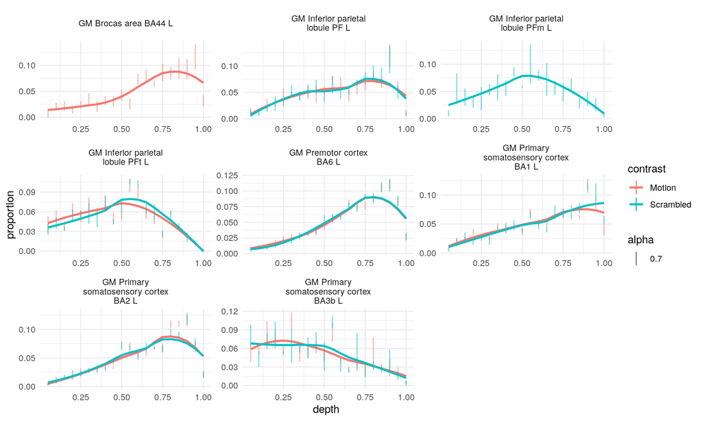

```r
library(ggthemes)

res %>%
  mutate(ROI = str_replace_all(ROI, "_", " ")) %>%
  ggplot( aes(x = depth, y = proportion, color = contrast) ) +
  geom_smooth(alpha = 0.5, se=F, n=20, na.rm = T, method = "loess") +
  geom_linerange(aes(ymin = proportion - error, ymax = proportion + error, color=contrast, alpha = 0.7)) +
  facet_wrap( ~ ROI, scales = "free", labeller = label_wrap_gen(width=22)) +
  theme_minimal()
```